# 1. Теория вероятностей и математическая статистика

```python
import warnings
from pathlib import Path

import numpy as np
import pandas as pd
import seaborn as sns
import matplotlib.pyplot as plt
import plotly.express as px

from IPython.display import display, Markdown
from scipy.stats import ks_2samp, mannwhitneyu, ttest_ind, kruskal, f_oneway

warnings.filterwarnings("ignore")
sns.set_theme(style="whitegrid", palette="deep")
plt.rcParams["figure.figsize"] = (11, 6)
plt.rcParams["axes.titlesize"] = 13
plt.rcParams["axes.labelsize"] = 11

RANDOM_STATE = 42
np.random.seed(RANDOM_STATE)
```

## 1.1. Загрузка данных

```python
def load_dataset() -> pd.DataFrame:
    local_paths = [
        Path("salaries.csv"),
        Path("data") / "salaries.csv",
        Path("dataset") / "salaries.csv",
    ]

    for path in local_paths:
        if path.exists():
            print(f"Loaded local dataset: {path}")
            return pd.read_csv(path)

    try:
        import kagglehub
        from kagglehub import KaggleDatasetAdapter

        print("Local CSV not found. Loading dataset via kagglehub...")
        return kagglehub.load_dataset(
            KaggleDatasetAdapter.PANDAS,
            "adilshamim8/salaries-for-data-science-jobs",
            "salaries.csv",
        )
    except Exception as exc:
        raise RuntimeError(
            "Dataset could not be loaded. Add a local 'salaries.csv' file or install kagglehub."
        ) from exc


df_raw = load_dataset()
df_raw.head()
```

```
Local CSV not found. Loading dataset via kagglehub...
```

|  | work_year | experience_level | employment_type | job_title | salary | salary_currency | salary_in_usd | employee_residence | remote_ratio | company_location | company_size |
| --- | --- | --- | --- | --- | --- | --- | --- | --- | --- | --- | --- |
| 0 | 2025 | EX | FT | Head of Data | 348516 | USD | 348516 | US | 0 | US | M |
| 1 | 2025 | EX | FT | Head of Data | 232344 | USD | 232344 | US | 0 | US | M |
| 2 | 2025 | SE | FT | Data Scientist | 145400 | USD | 145400 | US | 0 | US | M |
| 3 | 2025 | SE | FT | Data Scientist | 81600 | USD | 81600 | US | 0 | US | M |
| 4 | 2025 | MI | FT | Engineer | 160000 | USD | 160000 | US | 100 | US | M |

## 1.2. Подготовка переменных для статистического анализа

В этом разделе основной интерес представляет переменная `salary_in_usd`, поскольку именно она отражает итоговый уровень оплаты труда.

Дополнительно используем логарифм зарплаты `log_salary`, чтобы отдельно посмотреть, насколько сильна асимметрия исходного распределения и как оно меняется после логарифмирования.

В качестве ключевых сегментов для сравнения рассмотрим:

- уровень опыта;
- размер компании;
- формат работы.

```python
experience_map = {
    "EN": "Entry-level",
    "MI": "Mid-level",
    "SE": "Senior-level",
    "EX": "Executive-level",
}

company_size_map = {
    "S": "Small",
    "M": "Medium",
    "L": "Large",
}

df = df_raw.copy()
df = df.drop_duplicates()
df = df[df["salary_in_usd"].notna()].copy()
df = df[df["salary_in_usd"] > 0].copy()

df["experience_label"] = df["experience_level"].map(experience_map)
df["company_size_label"] = df["company_size"].map(company_size_map)

df["remote_mode"] = np.select(
    [
        df["remote_ratio"] == 0,
        df["remote_ratio"] == 50,
        df["remote_ratio"] == 100,
    ],
    [
        "On-site",
        "Hybrid",
        "Fully remote",
    ],
    default="Other",
)

df["log_salary"] = np.log(df["salary_in_usd"])

display(Markdown(f"**Размер выборки после очистки:** {df.shape[0]} наблюдений, {df.shape[1]} признаков."))
df[["salary_in_usd", "log_salary", "experience_label", "company_size_label", "remote_mode"]].head()
```

**Размер выборки после очистки:** 71913 наблюдений, 15 признаков.

|  | salary_in_usd | log_salary | experience_label | company_size_label | remote_mode |
| --- | --- | --- | --- | --- | --- |
| 0 | 348516 | 12.761439 | Executive-level | Medium | On-site |
| 1 | 232344 | 12.355974 | Executive-level | Medium | On-site |
| 2 | 145400 | 11.887244 | Senior-level | Medium | On-site |
| 3 | 81600 | 11.309585 | Senior-level | Medium | On-site |
| 4 | 160000 | 11.982929 | Mid-level | Medium | Fully remote |

## 1.3. Первичный взгляд на распределение зарплат

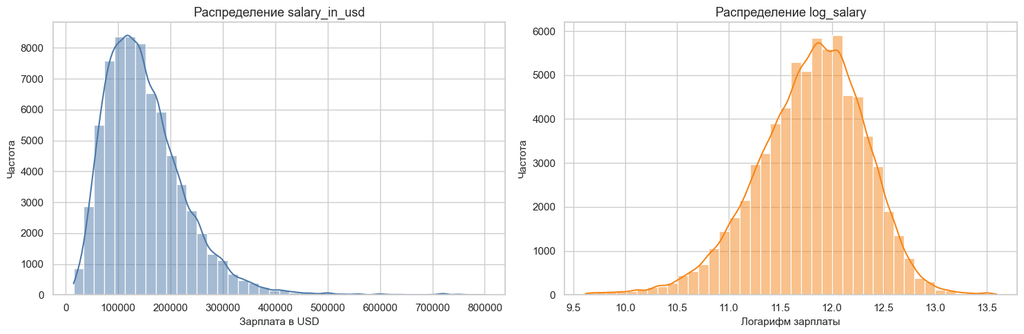

```python
fig, axes = plt.subplots(1, 2, figsize=(15, 5))

sns.histplot(df["salary_in_usd"], bins=40, kde=True, ax=axes[0], color="#4C78A8")
axes[0].set_title("Распределение salary_in_usd")
axes[0].set_xlabel("Зарплата в USD")
axes[0].set_ylabel("Частота")

sns.histplot(df["log_salary"], bins=40, kde=True, ax=axes[1], color="#F58518")
axes[1].set_title("Распределение log_salary")
axes[1].set_xlabel("Логарифм зарплаты")
axes[1].set_ylabel("Частота")

plt.tight_layout()
plt.show()
```

По графикам видно, что распределение `salary_in_usd` выраженно асимметрично вправо.

Основная масса наблюдений сосредоточена примерно в диапазоне до 200 тысяч USD, при этом справа тянется длинный хвост с редкими очень большими значениями, доходящими до 700–800 тысяч USD. Это типичная картина для зарплатных данных: большинство значений лежит в умеренном диапазоне, а небольшое число наблюдений формирует тяжёлый правый хвост.

После логарифмирования распределение `log_salary` становится заметно более компактным и ближе к симметричному. Это важное наблюдение для дальнейшей работы: уже на этапе визуального анализа видно, что логарифм зарплаты лучше подходит для моделирования, чем исходная переменная в уровнях.

## 1.4. Сравнение распределений между основными сегментами

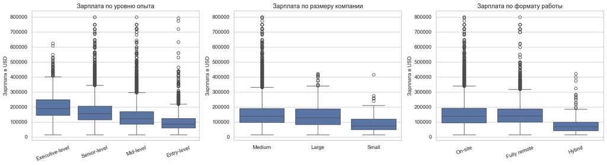

```python
fig, axes = plt.subplots(1, 3, figsize=(18, 5))

sns.boxplot(data=df, x="experience_label", y="salary_in_usd", ax=axes[0])
axes[0].set_title("Зарплата по уровню опыта")
axes[0].set_xlabel("")
axes[0].set_ylabel("Зарплата в USD")
axes[0].tick_params(axis="x", rotation=20)

sns.boxplot(data=df, x="company_size_label", y="salary_in_usd", ax=axes[1])
axes[1].set_title("Зарплата по размеру компании")
axes[1].set_xlabel("")
axes[1].set_ylabel("Зарплата в USD")

sns.boxplot(data=df, x="remote_mode", y="salary_in_usd", ax=axes[2])
axes[2].set_title("Зарплата по формату работы")
axes[2].set_xlabel("")
axes[2].set_ylabel("Зарплата в USD")
axes[2].tick_params(axis="x", rotation=20)

plt.tight_layout()
plt.show()
```

Сравнение boxplot показывает, что наиболее сильные различия наблюдаются по уровню опыта и по размеру компании.

По уровню опыта виден ожидаемый градиент: медианная зарплата снижается при переходе от `Executive-level` к `Entry-level`. Особенно заметен разрыв между `Senior-level` и `Entry-level`, причём различаются не только медианы, но и весь уровень распределения в целом. У более опытных специалистов зарплаты выше и верхний хвост распределения заметно длиннее.

По размеру компании различия тоже выражены достаточно чётко. В малых компаниях зарплаты в среднем по медиане ниже, чем в средних и крупных. При этом распределения `Medium` и `Large` достаточно похожи.

По формату работы картина менее однозначна. Распределения `On-site` и `Fully remote` визуально очень близки, а вот `Hybrid` заметно смещён вниз и выглядит более слабой группой по уровню зарплаты.

## 1.5. Количественное сравнение распределений через плотности, KS и PSI

Рассмотрим три пары групп:

- `Entry-level` против `Senior-level`;
- `Small` против `Large`;
- `On-site` против `Fully remote`.

Для каждой пары:

- сравниваем плотности на одном графике;
- считаем KS-статистику;
- считаем PSI.

Такой набор позволяет оценить различие распределений не только визуально, но и численно.

```python
def calculate_psi(expected, actual, bins=10):
    expected = pd.Series(expected).dropna().astype(float)
    actual = pd.Series(actual).dropna().astype(float)

    breaks = np.unique(np.quantile(expected, np.linspace(0, 1, bins + 1)))
    if len(breaks) < 3:
        return np.nan

    expected_hist, _ = np.histogram(expected, bins=breaks)
    actual_hist, _ = np.histogram(actual, bins=breaks)

    expected_pct = np.where(expected_hist == 0, 1e-6, expected_hist / expected_hist.sum())
    actual_pct = np.where(actual_hist == 0, 1e-6, actual_hist / actual_hist.sum())

    psi = np.sum((actual_pct - expected_pct) * np.log(actual_pct / expected_pct))
    return psi


def compare_distributions(data, group_col, target_col, group_a, group_b):
    sample_a = data.loc[data[group_col] == group_a, target_col].dropna()
    sample_b = data.loc[data[group_col] == group_b, target_col].dropna()

    ks_stat, ks_pvalue = ks_2samp(sample_a, sample_b)
    psi_value = calculate_psi(sample_a, sample_b)

    return pd.Series(
        {
            "group_a": group_a,
            "group_b": group_b,
            "n_a": len(sample_a),
            "n_b": len(sample_b),
            "mean_a": sample_a.mean(),
            "mean_b": sample_b.mean(),
            "median_a": sample_a.median(),
            "median_b": sample_b.median(),
            "ks_stat": ks_stat,
            "ks_pvalue": ks_pvalue,
            "psi": psi_value,
        }
    )
```

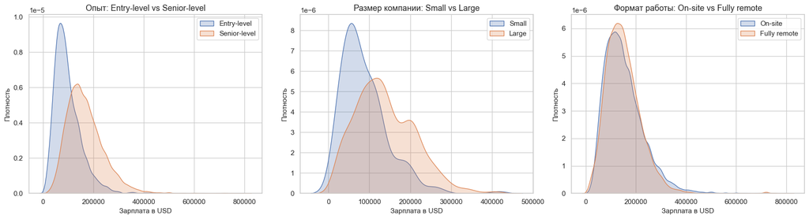

```python
fig, axes = plt.subplots(1, 3, figsize=(18, 5))

pairs = [
    ("experience_label", "Entry-level", "Senior-level", "Опыт: Entry-level vs Senior-level"),
    ("company_size_label", "Small", "Large", "Размер компании: Small vs Large"),
    ("remote_mode", "On-site", "Fully remote", "Формат работы: On-site vs Fully remote"),
]

for ax, (group_col, group_a, group_b, title) in zip(axes, pairs):
    sns.kdeplot(
        df.loc[df[group_col] == group_a, "salary_in_usd"],
        label=group_a,
        ax=ax,
        fill=True,
        alpha=0.25,
    )
    sns.kdeplot(
        df.loc[df[group_col] == group_b, "salary_in_usd"],
        label=group_b,
        ax=ax,
        fill=True,
        alpha=0.25,
    )
    ax.set_title(title)
    ax.set_xlabel("Зарплата в USD")
    ax.set_ylabel("Плотность")
    ax.legend()

plt.tight_layout()
plt.show()
```

```python
distribution_comparison = pd.DataFrame(
    [
        compare_distributions(df, "experience_label", "salary_in_usd", "Entry-level", "Senior-level"),
        compare_distributions(df, "company_size_label", "salary_in_usd", "Small", "Large"),
        compare_distributions(df, "remote_mode", "salary_in_usd", "On-site", "Fully remote"),
    ]
)

distribution_comparison.round(4)
```

|  | group_a | group_b | n_a | n_b | mean_a | mean_b | median_a | median_b | ks_stat | ks_pvalue | psi |
| --- | --- | --- | --- | --- | --- | --- | --- | --- | --- | --- | --- |
| 0 | Entry-level | Senior-level | 7975 | 37702 | 98017.0803 | 167807.9580 | 85469.0 | 156160.0 | 0.4610 | 0.0 | 1.3156 |
| 1 | Small | Large | 215 | 1588 | 87963.9581 | 137866.0730 | 75000.0 | 129300.0 | 0.3584 | 0.0 | 0.6597 |
| 2 | On-site | Fully remote | 54081 | 17505 | 152147.4612 | 149410.4494 | 138300.0 | 140000.0 | 0.0293 | 0.0 | 0.0171 |

Количественное сравнение распределений через KS и PSI хорошо согласуется с визуальными графиками.

Для пары `Entry-level` и `Senior-level` различие является самым сильным из всех рассмотренных. KS-статистика равна `0.461`, а PSI — `1.3156`, что указывает на очень заметный сдвиг распределений. Это подтверждается и простыми описательными статистиками: средняя зарплата у `Senior-level` составляет около `167.8` тыс. USD против `98.0` тыс. USD у `Entry-level`, а медиана — `156.2` тыс. USD против `85.5` тыс. USD.

Для пары `Small` и `Large` различие тоже выражено достаточно сильно. KS-статистика равна `0.3584`, а PSI — `0.6597`. Средняя зарплата в крупных компаниях составляет около `137.9` тыс. USD, тогда как в малых — около `88.0` тыс. USD. По медиане разрыв тоже заметен: `129.3` тыс. USD против `75.0` тыс. USD.

Для пары `On-site` и `Fully remote` картина принципиально иная. KS-статистика составляет всего `0.0293`, а PSI — `0.0171`, то есть распределения очень близки друг к другу. Это видно и по средним, и по медианам: различия между ними невелики, поэтому здесь нет оснований говорить о сильном структурном сдвиге между группами.

## 1.6. Формулировка статистических гипотез

### Гипотеза 1. Entry-level против Senior-level

- **H0:** распределение зарплат и центральные тенденции в группах `Entry-level` и `Senior-level` не различаются;
- **H1:** между этими группами есть различие.

Эта гипотеза выглядит наиболее естественной для данного датасета, потому что уровень опыта напрямую связан с квалификацией, сложностью задач и рыночной стоимостью специалиста.

### Гипотеза 2. Small против Large

- **H0:** уровень зарплат в малых и крупных компаниях не различается;
- **H1:** между этими группами есть различие.

Эта гипотеза позволяет проверить, есть ли систематическая разница в оплате между работодателями разного масштаба.

### Гипотеза 3. On-site против Fully remote

- **H0:** формат работы не связан с различием в уровне зарплаты;
- **H1:** между форматами работы есть различие.

Это уже более прикладная гипотеза, связанная с тем, что удаленная работа потенциально расширяет рынок вакансий и доступ к более дорогим позициям.

Для парных сравнений используем два теста:

- критерий Манна—Уитни как основной непараметрический инструмент;
- t-тест Уэлча как дополнительную проверку разницы средних.

```python
def bootstrap_diff_ci(sample_a, sample_b, stat_func=np.mean, n_boot=3000, alpha=0.05, random_state=42):
    rng = np.random.default_rng(random_state)
    sample_a = np.array(sample_a)
    sample_b = np.array(sample_b)

    diffs = []
    for _ in range(n_boot):
        boot_a = rng.choice(sample_a, size=len(sample_a), replace=True)
        boot_b = rng.choice(sample_b, size=len(sample_b), replace=True)
        diffs.append(stat_func(boot_a) - stat_func(boot_b))

    lower = np.quantile(diffs, alpha / 2)
    upper = np.quantile(diffs, 1 - alpha / 2)
    return lower, upper


def test_group_difference(data, group_col, target_col, group_a, group_b):
    sample_a = data.loc[data[group_col] == group_a, target_col].dropna()
    sample_b = data.loc[data[group_col] == group_b, target_col].dropna()

    _, mw_pvalue = mannwhitneyu(sample_a, sample_b, alternative="two-sided")
    _, t_pvalue = ttest_ind(sample_a, sample_b, equal_var=False)

    mean_diff = sample_a.mean() - sample_b.mean()
    median_diff = sample_a.median() - sample_b.median()

    ci_mean_low, ci_mean_high = bootstrap_diff_ci(sample_a, sample_b, stat_func=np.mean)
    ci_median_low, ci_median_high = bootstrap_diff_ci(sample_a, sample_b, stat_func=np.median)

    return pd.Series(
        {
            "group_a": group_a,
            "group_b": group_b,
            "n_a": len(sample_a),
            "n_b": len(sample_b),
            "mean_a": sample_a.mean(),
            "mean_b": sample_b.mean(),
            "median_a": sample_a.median(),
            "median_b": sample_b.median(),
            "mean_diff": mean_diff,
            "median_diff": median_diff,
            "mw_pvalue": mw_pvalue,
            "welch_t_pvalue": t_pvalue,
            "ci_mean_low": ci_mean_low,
            "ci_mean_high": ci_mean_high,
            "ci_median_low": ci_median_low,
            "ci_median_high": ci_median_high,
        }
    )
```

```python
hypothesis_results = pd.DataFrame(
    [
        test_group_difference(df, "experience_label", "salary_in_usd", "Entry-level", "Senior-level"),
        test_group_difference(df, "company_size_label", "salary_in_usd", "Small", "Large"),
        test_group_difference(df, "remote_mode", "salary_in_usd", "On-site", "Fully remote"),
    ]
)

hypothesis_results.round(4)
```

|  | group_a | group_b | n_a | n_b | mean_a | mean_b | median_a | median_b | mean_diff | median_diff | mw_pvalue | welch_t_pvalue | ci_mean_low | ci_mean_high | ci_median_low | ci_median_high |
| --- | --- | --- | --- | --- | --- | --- | --- | --- | --- | --- | --- | --- | --- | --- | --- | --- |
| 0 | Entry-level | Senior-level | 7975 | 37702 | 98017.0803 | 167807.9580 | 85469.0 | 156160.0 | -69790.8778 | -70691.0 | 0.0000 | 0.0 | -71225.3904 | -68273.2375 | -72083.20 | -69000.00 |
| 1 | Small | Large | 215 | 1588 | 87963.9581 | 137866.0730 | 75000.0 | 129300.0 | -49902.1149 | -54300.0 | 0.0000 | 0.0 | -57990.9501 | -40823.7977 | -64801.85 | -45798.75 |
| 2 | On-site | Fully remote | 54081 | 17505 | 152147.4612 | 149410.4494 | 138300.0 | 140000.0 | 2737.0118 | -1700.0 | 0.3662 | 0.0 | 1461.0730 | 4013.2181 | -3490.00 | -850.00 |

Результаты проверки гипотез показывают, что различия между сегментами выражены не одинаково.

Для пары `Entry-level` и `Senior-level` различие является и статистически значимым, и практически крупным. По критерию Манна—Уитни нулевая гипотеза отвергается (`p-value < 0.05`), аналогичный вывод даёт и t-тест Уэлча. Средняя зарплата `Entry-level` ниже примерно на `69.8` тыс. USD, а медианная — примерно на `70.7` тыс. USD. Бутстрэп-интервал для разницы средних `[-71.2; -68.3]` тыс. USD не содержит ноль, поэтому вывод о различии выглядит очень устойчивым.

Для пары `Small` и `Large` различие также статистически значимо и содержательно заметно. По обоим тестам нулевая гипотеза отвергается (`p-value < 0.05`). Средняя зарплата в малых компаниях ниже примерно на `49.9` тыс. USD, а медианная — на `54.3` тыс. USD. Бутстрэп-интервал для разницы средних `[-58.0; -40.8]` тыс. USD также не содержит ноль, что подтверждает устойчивость результата.

Для пары `On-site` и `Fully remote` картина более тонкая. По критерию Манна—Уитни статистически значимого различия обнаружить не удалось (`p-value = 0.3662`), то есть с точки зрения распределений в целом группы очень близки. При этом t-тест Уэлча показывает значимость, что, скорее всего, связано с очень большим объёмом выборки: даже небольшая разница средних в таких условиях может стать формально значимой. Однако практический размер эффекта здесь мал: средняя разница составляет всего около `2.7` тыс. USD, а медианная — около `-1.7` тыс. USD. Поэтому содержательно различие между `On-site` и `Fully remote` выглядит слабым.

## 1.7. Дополнительная проверка различий между всеми уровнями опыта

Помимо сравнения двух крайних групп, полезно отдельно проверить, различаются ли все уровни опыта в целом.

Для этого используем:

- критерий Краскела—Уоллиса как основной непараметрический тест;
- ANOVA как дополнительную параметрическую проверку.

```python
experience_groups = [
    group["salary_in_usd"].dropna().values
    for _, group in df.groupby("experience_label")
]

kruskal_stat, kruskal_p = kruskal(*experience_groups)
anova_stat, anova_p = f_oneway(*experience_groups)

pd.DataFrame(
    {
        "test": ["Kruskal-Wallis", "ANOVA"],
        "statistic": [kruskal_stat, anova_stat],
        "pvalue": [kruskal_p, anova_p],
    }
).round(4)
```

|  | test | statistic | pvalue |
| --- | --- | --- | --- |
| 0 | Kruskal-Wallis | 10010.5798 | 0.0 |
| 1 | ANOVA | 2838.2006 | 0.0 |

Результаты многогрупповой проверки показывают, что различия между уровнями опыта статистически значимы в целом.

И критерий Краскела—Уоллиса, и ANOVA дают `p-value < 0.05`, поэтому нулевая гипотеза о равенстве групп отвергается. Это означает, что уровень опыта действительно тесно связан с уровнем зарплаты в выборке, причём различия наблюдаются не только между крайними группами `Entry-level` и `Senior-level`, но и между сегментами опыта в целом.

Тем самым фактор опыта можно считать одним из самых сильных и содержательно важных признаков в данном исследовании.

## 1.8. Какая группа выглядит отстающей и возможные причины этого отставания

По результатам анализа наиболее слабой группой выглядит `Entry-level`.

Это видно сразу по нескольким признакам. Во-первых, у этой группы заметно ниже и средняя, и медианная зарплата по сравнению с `Senior-level`. Во-вторых, различие между распределениями велико не только визуально, но и количественно: KS-статистика и PSI указывают на сильный сдвиг. В-третьих, бутстрэп-интервал для разницы средних полностью лежит ниже нуля, что делает вывод устойчивым.

Такой результат выглядит ожидаемым. Во-первых, начинающие специалисты в среднем обладают меньшим опытом и более узким набором навыков, поэтому их рыночная стоимость ниже. Во-вторых, они обычно имеют меньшую переговорную силу, реже занимают наиболее дорогие роли и в среднем слабее представлены в сегментах рынка с максимальной оплатой.

## 1.9. Идеи экспериментов

Можно предложить несколько идей для условных экспериментов для уменьшения отставания `Entry-level`:

- проверить, увеличивается ли привлекательность junior-вакансий при расширении удалённого формата;
- протестировать пересмотр стартовых компенсационных вилок;
- оценить эффект программ наставничества и ускоренного карьерного роста, которые помогают быстрее переводить специалистов в более высокооплачиваемые категории.

## 1.10. Вывод по разделу

В этом разделе было показано, что распределение зарплат в датасете выраженно асимметрично и имеет длинный правый хвост, что типично для зарплатных данных. Логарифмирование переменной делает распределение заметно более стабильным и удобным для дальнейшего анализа.

Сравнение между сегментами показало, что наиболее сильные различия наблюдаются по уровню опыта и по размеру компании. Особенно большой разрыв обнаружен между `Entry-level` и `Senior-level`: различаются и средние, и медианы, и форма распределения в целом. Существенная разница также наблюдается между малыми и крупными компаниями.

Для формата работы ситуация оказалась более сдержанной: распределения `On-site` и `Fully remote` близки друг к другу, а практический размер различия невелик. В результате основной отстающей группой по итогам раздела можно считать `Entry-level`, для которой были предложены возможные содержательные объяснения и прикладные идеи улучшения ситуации.

# 2. Регрессионный анализ

## 2.1. Подготовка данных для регрессионного анализа

Для моделирования используем несколько факторов, которые выглядят наиболее содержательными для данного датасета:

- уровень опыта;
- размер компании;
- формат работы;
- тип занятости;
- год наблюдения.

Дополнительно во второй спецификации введём `log_salary` как альтернативную зависимую переменную. Это позволит проверить, станет ли модель устойчивее после перехода к логарифмам.

```python
import statsmodels.api as sm
import statsmodels.formula.api as smf

from sklearn.metrics import mean_absolute_error, mean_squared_error
from statsmodels.stats.diagnostic import het_breuschpagan, het_white
from statsmodels.stats.outliers_influence import variance_inflation_factor
from statsmodels.graphics.gofplots import qqplot
```

```python
employment_map = {
    "FT": "Full-time",
    "PT": "Part-time",
    "CT": "Contract",
    "FL": "Freelance",
}

df["employment_label"] = df["employment_type"].map(employment_map).fillna(df["employment_type"])
df["log_salary"] = np.log(df["salary_in_usd"])

model_df = df.dropna(
    subset=[
        "salary_in_usd",
        "log_salary",
        "experience_label",
        "company_size_label",
        "remote_mode",
        "employment_label",
        "work_year",
    ]
).copy()

display(
    Markdown(
        f"**Размер регрессионной выборки:** {model_df.shape[0]} наблюдений, {model_df.shape[1]} признаков."
    )
)

model_df[
    [
        "salary_in_usd",
        "log_salary",
        "experience_label",
        "company_size_label",
        "remote_mode",
        "employment_label",
        "work_year",
    ]
].head()
```

**Размер регрессионной выборки:** 71913 наблюдений, 16 признаков.

|  | salary_in_usd | log_salary | experience_label | company_size_label | remote_mode | employment_label | work_year |
| --- | --- | --- | --- | --- | --- | --- | --- |
| 0 | 348516 | 12.761439 | Executive-level | Medium | On-site | Full-time | 2025 |
| 1 | 232344 | 12.355974 | Executive-level | Medium | On-site | Full-time | 2025 |
| 2 | 145400 | 11.887244 | Senior-level | Medium | On-site | Full-time | 2025 |
| 3 | 81600 | 11.309585 | Senior-level | Medium | On-site | Full-time | 2025 |
| 4 | 160000 | 11.982929 | Mid-level | Medium | Fully remote | Full-time | 2025 |

## 2.2. Почему здесь уместно логарифмирование зарплаты

Зарплатные данные обычно имеют выраженную правостороннюю асимметрию: относительно небольшая доля очень высоких значений сильно растягивает правый хвост распределения.

Для регрессии это важно, потому что модель в уровнях часто начинает страдать от нестабильной дисперсии остатков и чувствительности к выбросам.

Поэтому здесь специально сравним две спецификации:

1. модель на исходной переменной `salary_in_usd`;
2. модель на `log_salary`.

Если логарифмическая модель ведёт себя устойчивее, это будет аргументом в пользу её выбора как финальной.

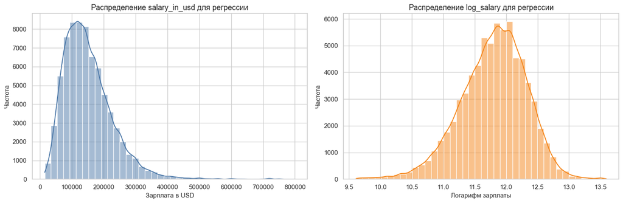

```python
fig, axes = plt.subplots(1, 2, figsize=(15, 5))

sns.histplot(model_df["salary_in_usd"], bins=40, kde=True, ax=axes[0], color="#4C78A8")
axes[0].set_title("Распределение salary_in_usd для регрессии")
axes[0].set_xlabel("Зарплата в USD")
axes[0].set_ylabel("Частота")

sns.histplot(model_df["log_salary"], bins=40, kde=True, ax=axes[1], color="#F58518")
axes[1].set_title("Распределение log_salary для регрессии")
axes[1].set_xlabel("Логарифм зарплаты")
axes[1].set_ylabel("Частота")

plt.tight_layout()
plt.show()
```

По этим графикам хорошо видно, почему в регрессионном разделе имеет смысл отдельно рассматривать логарифм зарплаты.

Распределение `salary_in_usd` остаётся выраженно асимметричным вправо: основная масса наблюдений сосредоточена в относительно умеренном диапазоне, а справа сохраняется длинный хвост с редкими очень высокими значениями. Это означает, что модель в исходной шкале будет вынуждена одновременно описывать и типичные зарплаты, и экстремально большие наблюдения, что часто ухудшает поведение остатков.

После логарифмирования распределение `log_salary` становится заметно более компактным и ближе к симметричному. Правый хвост уже не выглядит таким тяжёлым, а сама переменная оказывается лучше приспособлена для линейного моделирования.

Именно поэтому логарифмирование здесь используется не как формальный приём, а как содержательная попытка сделать модель устойчивее: уменьшить влияние экстремально больших зарплат, ослабить проблему неоднородности ошибок и получить более аккуратную спецификацию для дальнейшего сравнения.

## 2.3. Оценка коэффициентов базовой модели

```python
formula_1 = (
    "salary_in_usd ~ "
    "C(experience_label) + "
    "C(company_size_label) + "
    "C(remote_mode) + "
    "C(employment_label) + "
    "work_year"
)

model_1 = smf.ols(formula=formula_1, data=model_df).fit()

display(Markdown("**Модель 1. Базовая спецификация на `salary_in_usd`**"))
display(model_1.summary())
```

**Модель 1. Базовая спецификация на `salary_in_usd`**

OLS Regression Results

| Dep. Variable: | salary_in_usd | R-squared: | 0.112 |
| --- | --- | --- | --- |
| Model: | OLS | Adj. R-squared: | 0.112 |
| Method: | Least Squares | F-statistic: | 826.3 |
| Date: | Sat, 02 May 2026 | Prob (F-statistic): | 0.00 |
| Time: | 17:46:43 | Log-Likelihood: | -9.0720e+05 |
| No. Observations: | 71913 | AIC: | 1.814e+06 |
| Df Residuals: | 71901 | BIC: | 1.815e+06 |
| Df Model: | 11 |  |  |
| Covariance Type: | nonrobust |  |  |

|  | coef | std err | t | P>\|t\| | [0.025 | 0.975] |
| --- | --- | --- | --- | --- | --- | --- |
| Intercept | -3.064e+06 | 7.93e+05 | -3.866 | 0.000 | -4.62e+06 | -1.51e+06 |
| C(experience_label)[T.Executive-level] | 1.021e+05 | 1596.938 | 63.922 | 0.000 | 9.89e+04 | 1.05e+05 |
| C(experience_label)[T.Mid-level] | 3.683e+04 | 949.707 | 38.781 | 0.000 | 3.5e+04 | 3.87e+04 |
| C(experience_label)[T.Senior-level] | 6.835e+04 | 907.026 | 75.361 | 0.000 | 6.66e+04 | 7.01e+04 |
| C(company_size_label)[T.Medium] | 190.2756 | 1953.577 | 0.097 | 0.922 | -3638.729 | 4019.280 |
| C(company_size_label)[T.Small] | -3.244e+04 | 5373.549 | -6.037 | 0.000 | -4.3e+04 | -2.19e+04 |
| C(remote_mode)[T.Hybrid] | -4.049e+04 | 4331.762 | -9.346 | 0.000 | -4.9e+04 | -3.2e+04 |
| C(remote_mode)[T.On-site] | 5513.8285 | 639.092 | 8.628 | 0.000 | 4261.211 | 6766.446 |
| C(employment_label)[T.Freelance] | -2.856e+04 | 1.88e+04 | -1.523 | 0.128 | -6.53e+04 | 8190.496 |
| C(employment_label)[T.Full-time] | 3.008e+04 | 3743.140 | 8.037 | 0.000 | 2.27e+04 | 3.74e+04 |
| C(employment_label)[T.Part-time] | -8687.4222 | 5391.234 | -1.611 | 0.107 | -1.93e+04 | 1879.379 |
| work_year | 1545.9725 | 391.639 | 3.947 | 0.000 | 778.362 | 2313.583 |

| Omnibus: | 26382.894 | Durbin-Watson: | 1.732 |
| --- | --- | --- | --- |
| Prob(Omnibus): | 0.000 | Jarque-Bera (JB): | 162692.992 |
| Skew: | 1.640 | Prob(JB): | 0.00 |
| Kurtosis: | 9.598 | Cond. No. | 5.91e+06 |

Notes:  
[1] Standard Errors assume that the covariance matrix of the errors is correctly specified.  
[2] The condition number is large, 5.91e+06. This might indicate that there are  
strong multicollinearity or other numerical problems.

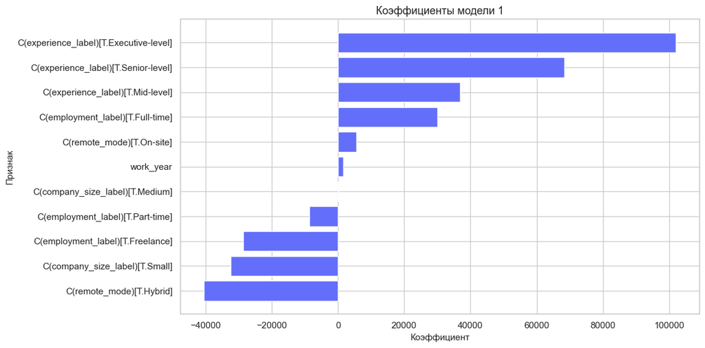

```python
coef_table_1 = model_1.params.to_frame("coef")

coef_plot_1 = (
    coef_table_1.reset_index()
    .rename(columns={"index": "term"})
    .query("term != 'Intercept'")
    .sort_values("coef")
)

plt.figure(figsize=(12, 6))
plt.barh(coef_plot_1["term"], coef_plot_1["coef"], color="#636EFA")
plt.title("Коэффициенты модели 1")
plt.xlabel("Коэффициент")
plt.ylabel("Признак")
plt.tight_layout()
plt.show()
```

По результатам оценки базовой модели видно, что она статистически значима в целом: `Prob(F-statistic) = 0.00`, то есть совокупность включённых факторов действительно связана с уровнем зарплаты.

При этом объясняющая способность модели остаётся умеренной: `R-squared = 0.112`. Это означает, что модель объясняет около `11.2%` вариации зарплаты. Для кросс-секционных зарплатных данных такой результат не является неожиданным: на уровень оплаты влияет много ненаблюдаемых факторов, которые не попали в спецификацию, например конкретный стек навыков, работодатель, специализация внутри роли и индивидуальная переговорная сила.

Наиболее сильными и содержательно понятными коэффициентами уже на этом этапе выглядят признаки, связанные с опытом. По сравнению с базовой группой `Entry-level` зарплата у `Mid-level` выше примерно на `36.8` тыс. USD, у `Senior-level` — на `68.4` тыс. USD, а у `Executive-level` — более чем на `102` тыс. USD. Это хорошо согласуется с результатами первого раздела, где фактор опыта уже оказался одним из самых сильных источников различий между группами.

По размеру компании важен прежде всего коэффициент для `Small`: он отрицателен и составляет примерно `-32.4` тыс. USD относительно базовой категории. Это означает, что после учёта остальных факторов работа в малой компании связана с более низкой ожидаемой зарплатой. Коэффициент для `Medium` статистически незначим, поэтому уверенно говорить о различии между `Medium` и базовой группой по этой модели нельзя.

По формату работы гибридный режим связан со снижением ожидаемой зарплаты примерно на `40.5` тыс. USD относительно базовой категории и является достаточно важным фактором, тогда как коэффициент для `On-site` положителен и составляет около `5.5` тыс. USD, что является очень маленьким приростом на фоне вышеперечисленных факторов.

Наконец, коэффициент при `work_year` положителен и статистически значим, но его величина сравнительно невелика: в среднем он даёт прибавку порядка `1.5` тыс. USD на год. Это можно трактовать как слабый общий тренд роста зарплат во времени, но не как ключевой драйвер различий в модели.

Уже по summary видно и первое предупреждение о проблемах модели. Остатки далеки от нормальности: `Omnibus` и `Jarque-Bera` дают `p-value = 0.00`, асимметрия положительна (`Skew = 1.640`), а эксцесс высок (`Kurtosis = 9.598`). Это не доказывает автоматически нарушение всех предпосылок, но явно показывает, что модель в исходной шкале зарплаты требует дополнительной диагностики.

## 2.4. Проверка предпосылок базовой модели

После интерпретации коэффициентов нужно отдельно проверить, насколько корректно ведёт себя сама модель.

В этом блоке рассмотрим три вещи:

- есть ли гетероскедастичность, то есть меняется ли разброс ошибок по мере роста предсказанных значений;
- есть ли заметные отклонения распределения остатков от нормальности;
- нет ли серьёзной мультиколлинеарности между объясняющими признаками.

Для зарплатных данных это особенно важно. Даже если коэффициенты выглядят содержательно разумными, модель в уровнях может плохо вести себя статистически: ошибки начинают расти вместе с зарплатой, распределение остатков оказывается сильно асимметричным, а стандартные ошибки коэффициентов становятся менее надёжными.

```python
def heteroskedasticity_report(model, model_name: str) -> pd.Series:
    exog = model.model.exog
    residuals = model.resid
    bp_test = het_breuschpagan(residuals, exog)

    return pd.Series(
        {
            "model": model_name,
            "bp_lm_stat": bp_test[0],
            "bp_lm_pvalue": bp_test[1],
        }
    )


hetero_model_1 = pd.DataFrame(
    [
        heteroskedasticity_report(model_1, "Model 1"),
    ]
)

hetero_model_1.round(4)
```

|  | model | bp_lm_stat | bp_lm_pvalue |
| --- | --- | --- | --- |
| 0 | Model 1 | 305.8576 | 0.0 |

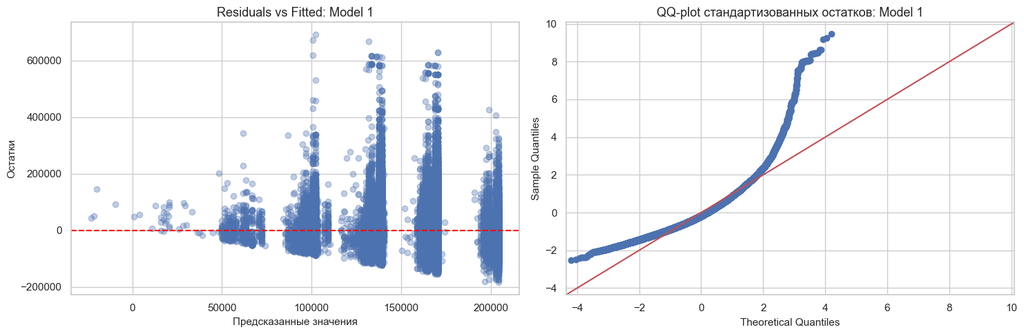

```python
influence_1 = model_1.get_influence()
standardized_residuals_1 = influence_1.resid_studentized_internal

fig, axes = plt.subplots(1, 2, figsize=(15, 5))

axes[0].scatter(model_1.fittedvalues, model_1.resid, alpha=0.35)
axes[0].axhline(0, color="red", linestyle="--")
axes[0].set_title("Residuals vs Fitted: Model 1")
axes[0].set_xlabel("Предсказанные значения")
axes[0].set_ylabel("Остатки")

qqplot(standardized_residuals_1, line="45", ax=axes[1])
axes[1].set_title("QQ-plot стандартизованных остатков: Model 1")

plt.tight_layout()
plt.show()
```

```python
def calculate_vif(dataframe: pd.DataFrame, formula: str) -> pd.DataFrame:
    fitted = smf.ols(formula=formula, data=dataframe)
    X = fitted.exog
    names = fitted.exog_names

    return pd.DataFrame(
        {
            "feature": names,
            "VIF": [variance_inflation_factor(X, i) for i in range(X.shape[1])],
        }
    )


vif_model_1 = calculate_vif(model_df, formula_1)
vif_model_1.sort_values("VIF", ascending=False).round(4).head(20)
```

|  | feature | VIF |
| --- | --- | --- |
| 0 | Intercept | 8.509385e+06 |
| 3 | C(experience_label)[T.Senior-level] | 2.779100e+00 |
| 2 | C(experience_label)[T.Mid-level] | 2.681200e+00 |
| 9 | C(employment_label)[T.Full-time] | 1.958500e+00 |
| 10 | C(employment_label)[T.Part-time] | 1.912000e+00 |
| 1 | C(experience_label)[T.Executive-level] | 1.310600e+00 |
| 4 | C(company_size_label)[T.Medium] | 1.263500e+00 |
| 5 | C(company_size_label)[T.Small] | 1.165700e+00 |
| 6 | C(remote_mode)[T.Hybrid] | 1.150400e+00 |
| 11 | work_year | 1.080500e+00 |
| 8 | C(employment_label)[T.Freelance] | 1.059500e+00 |
| 7 | C(remote_mode)[T.On-site] | 1.031600e+00 |

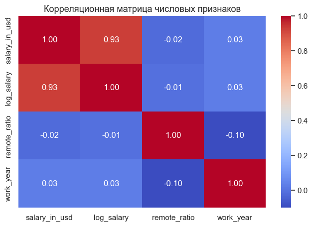

```python
numeric_cols = ["salary_in_usd", "log_salary", "remote_ratio", "work_year"]

plt.figure(figsize=(8, 5))
sns.heatmap(model_df[numeric_cols].corr(numeric_only=True), annot=True, cmap="coolwarm", fmt=".2f")
plt.title("Корреляционная матрица числовых признаков")
plt.show()
```

Результаты диагностики показывают, что главная проблема базовой модели связана именно с поведением остатков, а не с сильной зависимостью признаков между собой.

Во-первых, тест Бройша—Пагана даёт `bp_lm_stat = 305.8576` и `p-value = 0.00`. Это означает, что гипотеза о постоянной дисперсии ошибок отвергается, то есть в модели присутствует гетероскедастичность. Для зарплатных данных такой результат вполне ожидаем: чем выше предсказанный уровень зарплаты, тем больше становится и разброс ошибок.

Во-вторых, график `Residuals vs Fitted` поддерживает этот вывод визуально. Облако остатков распределено неравномерно: по мере роста предсказанных значений разброс ошибок увеличивается, а сами остатки становятся менее стабильными. Кроме того, заметны крупные положительные выбросы, особенно в области высоких зарплат. Это указывает на то, что модель в исходной шкале плохо справляется с правым хвостом распределения.

В-третьих, QQ-plot стандартизованных остатков показывает заметное отклонение от диагонали, особенно в хвостах распределения. Это согласуется с тем, что было видно в summary: остатки не выглядят нормально распределёнными, имеют асимметрию и тяжёлые хвосты. Для больших выборок нарушение нормальности само по себе не является катастрофой, но в сочетании с гетероскедастичностью оно усиливает сомнения в том, что модель в уровнях является хорошей финальной спецификацией.

При этом проверка мультиколлинеарности выглядит спокойной. Все содержательные значения VIF находятся примерно в диапазоне от `1.03` до `2.78`, что не указывает на серьёзную проблему. Самые крупные значения связаны с dummy-переменными уровня опыта, но даже они остаются на комфортном уровне. Это означает, что главная слабость модели — не в том, что признаки дублируют друг друга, а в том, как ведут себя ошибки модели.

Корреляционная матрица в этом блоке построена только для числовых признаков. Категориальные переменные вроде опыта, формата работы и размера компании здесь не показаны, потому что в исходном виде для обычной корреляции Пирсона они не подходят. Для них основная диагностика мультиколлинеарности как раз и идёт через VIF после dummy-кодирования.

## 2.5. Корректирующие действия

После диагностики уже можно довольно уверенно сказать, что базовая модель полезна как отправная точка, но не выглядит лучшим кандидатом на финальную спецификацию.

У неё есть два явных ограничения:

- дисперсия ошибок непостоянна;
- высокие зарплаты и тяжёлый правый хвост заметно искажают поведение остатков.

Поэтому следующий шаг в этой работе выглядит естественным: перейти от `salary_in_usd` к `log_salary` и одновременно использовать робастные стандартные ошибки.

Почему это должно помочь:

- логарифмирование сжимает правый хвост распределения и уменьшает влияние экстремально больших значений;
- различия между очень большими и умеренными зарплатами становятся менее перекошенными по масштабу;
- остатки часто ведут себя стабильнее;
- интерпретация коэффициентов в логарифмах удобнее, потому что эффекты можно читать как относительные изменения.

Именно таким образом вторая спецификация будет не просто альтернативной, а статистически более обоснованной версией первой модели.

## 2.6. Вторая спецификация: логарифмическая модель

Теперь оценим вторую модель, где зависимой переменной выступает `log_salary`.

В этой спецификации коэффициенты уже интерпретируются не в долларах, а примерно как относительные изменения зарплаты, что делает выводы более удобными и часто более устойчивыми.

```python
formula_2 = (
    "log_salary ~ "
    "C(experience_label) + "
    "C(company_size_label) + "
    "C(remote_mode) + "
    "C(employment_label) + "
    "work_year"
)

model_2 = smf.ols(formula=formula_2, data=model_df).fit(cov_type="HC3")

display(Markdown("**Модель 2. Логарифмическая спецификация с робастными стандартными ошибками HC3**"))
display(model_2.summary())
```

**Модель 2. Логарифмическая спецификация с робастными стандартными ошибками HC3**

OLS Regression Results

| Dep. Variable: | log_salary | R-squared: | 0.160 |
| --- | --- | --- | --- |
| Model: | OLS | Adj. R-squared: | 0.160 |
| Method: | Least Squares | F-statistic: | 1088. |
| Date: | Sat, 02 May 2026 | Prob (F-statistic): | 0.00 |
| Time: | 17:46:45 | Log-Likelihood: | -49112. |
| No. Observations: | 71913 | AIC: | 9.825e+04 |
| Df Residuals: | 71901 | BIC: | 9.836e+04 |
| Df Model: | 11 |  |  |
| Covariance Type: | HC3 |  |  |

|  | coef | std err | z | P>\|z\| | [0.025 | 0.975] |
| --- | --- | --- | --- | --- | --- | --- |
| Intercept | -3.8491 | 5.274 | -0.730 | 0.465 | -14.186 | 6.488 |
| C(experience_label)[T.Executive-level] | 0.7618 | 0.010 | 75.608 | 0.000 | 0.742 | 0.782 |
| C(experience_label)[T.Mid-level] | 0.3298 | 0.007 | 47.971 | 0.000 | 0.316 | 0.343 |
| C(experience_label)[T.Senior-level] | 0.5672 | 0.006 | 87.721 | 0.000 | 0.555 | 0.580 |
| C(company_size_label)[T.Medium] | 0.0146 | 0.014 | 1.033 | 0.302 | -0.013 | 0.042 |
| C(company_size_label)[T.Small] | -0.3322 | 0.047 | -7.116 | 0.000 | -0.424 | -0.241 |
| C(remote_mode)[T.Hybrid] | -0.4572 | 0.036 | -12.813 | 0.000 | -0.527 | -0.387 |
| C(remote_mode)[T.On-site] | 0.0261 | 0.004 | 6.437 | 0.000 | 0.018 | 0.034 |
| C(employment_label)[T.Freelance] | -0.3646 | 0.142 | -2.564 | 0.010 | -0.643 | -0.086 |
| C(employment_label)[T.Full-time] | 0.3210 | 0.034 | 9.572 | 0.000 | 0.255 | 0.387 |
| C(employment_label)[T.Part-time] | -0.1099 | 0.045 | -2.423 | 0.015 | -0.199 | -0.021 |
| work_year | 0.0073 | 0.003 | 2.818 | 0.005 | 0.002 | 0.012 |

| Omnibus: | 1358.409 | Durbin-Watson: | 1.638 |
| --- | --- | --- | --- |
| Prob(Omnibus): | 0.000 | Jarque-Bera (JB): | 1735.066 |
| Skew: | -0.259 | Prob(JB): | 0.00 |
| Kurtosis: | 3.558 | Cond. No. | 5.91e+06 |

Notes:  
[1] Standard Errors are heteroscedasticity robust (HC3)  
[2] The condition number is large, 5.91e+06. This might indicate that there are  
strong multicollinearity or other numerical problems.

```python
coef_table = model_2.params.to_frame("coef")
coef_table["pvalue"] = model_2.pvalues
coef_table["pct_effect"] = (np.exp(coef_table["coef"]) - 1) * 100

coef_table.sort_values("pvalue").round(4).head(20)
```

|  | coef | pvalue | pct_effect |
| --- | --- | --- | --- |
| C(experience_label)[T.Executive-level] | 0.7618 | 0.0000 | 114.2134 |
| C(experience_label)[T.Mid-level] | 0.3298 | 0.0000 | 39.0632 |
| C(experience_label)[T.Senior-level] | 0.5672 | 0.0000 | 76.3276 |
| C(remote_mode)[T.Hybrid] | -0.4572 | 0.0000 | -36.6944 |
| C(employment_label)[T.Full-time] | 0.3210 | 0.0000 | 37.8561 |
| C(company_size_label)[T.Small] | -0.3322 | 0.0000 | -28.2624 |
| C(remote_mode)[T.On-site] | 0.0261 | 0.0000 | 2.6395 |
| work_year | 0.0073 | 0.0048 | 0.7370 |
| C(employment_label)[T.Freelance] | -0.3646 | 0.0103 | -30.5519 |
| C(employment_label)[T.Part-time] | -0.1099 | 0.0154 | -10.4086 |
| C(company_size_label)[T.Medium] | 0.0146 | 0.3017 | 1.4735 |
| Intercept | -3.8491 | 0.4655 | -97.8701 |

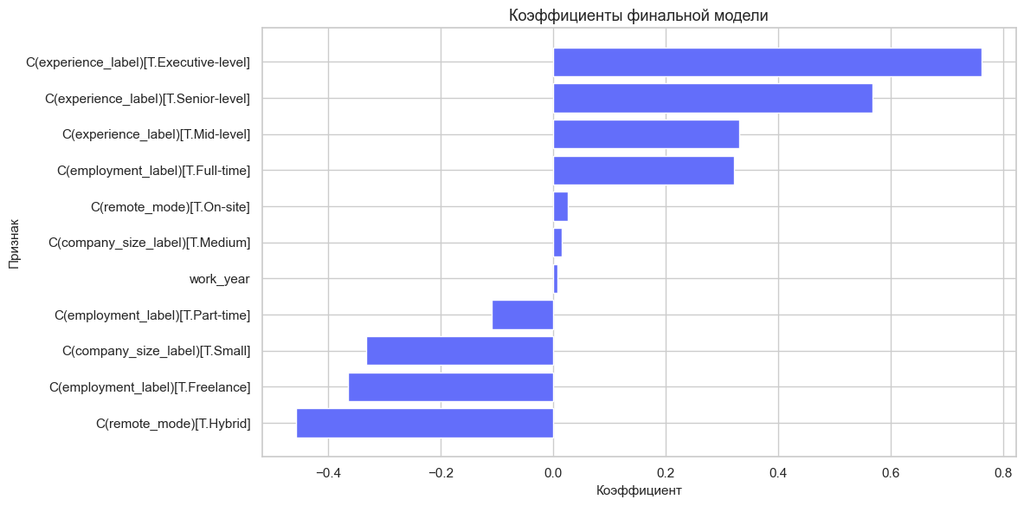

```python
coef_plot = (
    coef_table.reset_index()
    .rename(columns={"index": "term"})
    .query("term != 'Intercept'")
    .sort_values("coef")
)

plt.figure(figsize=(12, 6))
plt.barh(coef_plot["term"], coef_plot["coef"], color="#636EFA")
plt.title("Коэффициенты финальной модели")
plt.xlabel("Коэффициент")
plt.ylabel("Признак")
plt.tight_layout()
plt.show()
```

Логарифмическая модель выглядит содержательно сильнее и удобнее для интерпретации, чем базовая спецификация в уровнях.

Во-первых, она по-прежнему подтверждает, что главным фактором различий в зарплатах остаётся опыт. По сравнению с базовой группой `Entry-level` переход к `Mid-level` связан примерно с ростом ожидаемой зарплаты на `39.1%`, к `Senior-level` — на `76.3%`, а к `Executive-level` — более чем на `114%`. Это очень сильные эффекты, и они хорошо согласуются как с первым разделом, так и с результатами модели на `salary_in_usd`.

Во-вторых, логарифмическая спецификация подтверждает заметный отрицательный эффект для `Small` компаний: по сравнению с базовой категорией ожидаемая зарплата у них ниже примерно на `28.3%`. При этом коэффициент для `Medium` статистически незначим (`p-value = 0.3017`), поэтому различие между `Medium` и базовой группой по этой модели нельзя считать убедительно подтверждённым.

В-третьих, Формат работы в логарифмической модели показывает неоднородный эффект. Гибридный формат связан со снижением ожидаемой зарплаты примерно на `36.7%` и является не только статистически значимым, но и содержательно крупным фактором. Напротив, для `On-site` эффект положителен, но по масштабу невелик и составляет около `2.6%`.

Отдельно стоит отметить тип занятости. Полная занятость (`Full-time`) связана с более высокой ожидаемой зарплатой примерно на `37.9%`, тогда как `Freelance` и `Part-time` дают отрицательные эффекты — примерно `-30.6%` и `-10.4%` соответственно. Коэффициент при `work_year` остаётся положительным, но по масштабу он невелик: это около `0.74%` роста ожидаемой зарплаты на один год.

Важный итог этого блока состоит в том, что после перехода к логарифмам основные содержательные эффекты не исчезли, а стали даже удобнее для интерпретации: теперь их можно обсуждать в относительных изменениях, что для зарплатных данных обычно естественнее, чем абсолютные изменения в долларах.

## 2.7. Повторная диагностика для второй модели

После оценки логарифмической модели важно снова проверить поведение остатков и посмотреть, действительно ли вторая спецификация улучшает модель с точки зрения статистических свойств.

Здесь нас интересуют три вещи:

- стала ли форма остатков более спокойной;
- уменьшились ли отклонения от нормальности;
- не появилась ли серьёзная мультиколлинеарность при переходе к новой постановке.

При этом важно помнить, что логарифмирование не обязано полностью устранить все проблемы модели. Его задача — сделать их слабее и получить более устойчивую спецификацию по сравнению с базовой моделью.

```python
hetero_comparison = pd.DataFrame(
    [
        heteroskedasticity_report(model_1, "Model 1"),
        heteroskedasticity_report(model_2, "Model 2"),
    ]
)

hetero_comparison.round(4)
```

|  | model | bp_lm_stat | bp_lm_pvalue |
| --- | --- | --- | --- |
| 0 | Model 1 | 305.8576 | 0.0 |
| 1 | Model 2 | 862.1278 | 0.0 |

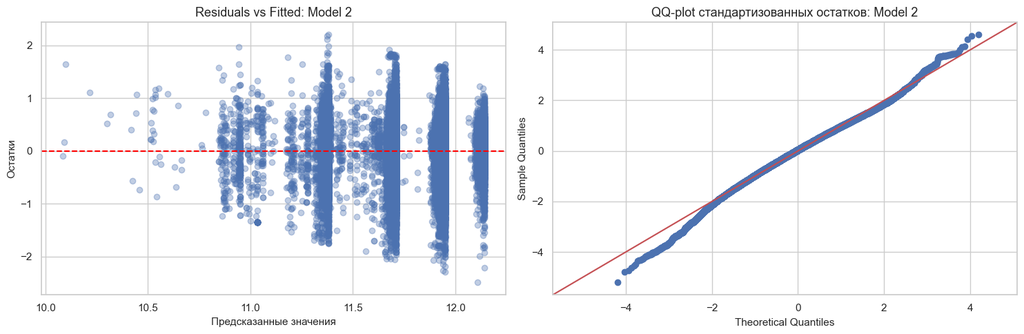

```python
influence_2 = model_2.get_influence()
standardized_residuals_2 = influence_2.resid_studentized_internal

fig, axes = plt.subplots(1, 2, figsize=(15, 5))

axes[0].scatter(model_2.fittedvalues, model_2.resid, alpha=0.35)
axes[0].axhline(0, color="red", linestyle="--")
axes[0].set_title("Residuals vs Fitted: Model 2")
axes[0].set_xlabel("Предсказанные значения")
axes[0].set_ylabel("Остатки")

qqplot(standardized_residuals_2, line="45", ax=axes[1])
axes[1].set_title("QQ-plot стандартизованных остатков: Model 2")

plt.tight_layout()
plt.show()
```

```python
vif_model_2 = calculate_vif(model_df, formula_2)
vif_model_2.sort_values("VIF", ascending=False).round(4).head(20)
```

|  | feature | VIF |
| --- | --- | --- |
| 0 | Intercept | 8.509385e+06 |
| 3 | C(experience_label)[T.Senior-level] | 2.779100e+00 |
| 2 | C(experience_label)[T.Mid-level] | 2.681200e+00 |
| 9 | C(employment_label)[T.Full-time] | 1.958500e+00 |
| 10 | C(employment_label)[T.Part-time] | 1.912000e+00 |
| 1 | C(experience_label)[T.Executive-level] | 1.310600e+00 |
| 4 | C(company_size_label)[T.Medium] | 1.263500e+00 |
| 5 | C(company_size_label)[T.Small] | 1.165700e+00 |
| 6 | C(remote_mode)[T.Hybrid] | 1.150400e+00 |
| 11 | work_year | 1.080500e+00 |
| 8 | C(employment_label)[T.Freelance] | 1.059500e+00 |
| 7 | C(remote_mode)[T.On-site] | 1.031600e+00 |

Повторная диагностика показывает, что переход к логарифмической модели дал смешанный, но в целом полезный результат.

С одной стороны, гетероскедастичность полностью не исчезла. Для второй модели `Breusch–Pagan` по-прежнему отвергает гипотезу о постоянной дисперсии ошибок (`p-value = 0.00`), причём значение статистики даже выше, чем у первой модели. Это означает, что логарифмирование не решило проблему неоднородности дисперсии окончательно.

С другой стороны, распределение остатков стало заметно лучше по форме. По summary второй модели видно, что асимметрия снизилась с `1.640` до `-0.259`, а эксцесс — с `9.598` до `3.558`. То есть остатки стали гораздо ближе к симметричному и менее тяжёлыми по хвостам. В большой выборке тесты нормальности всё равно продолжают отвергать идеальную нормальность (`Prob(Omnibus) = 0.00`, `Prob(JB) = 0.00`), но содержательно поведение остатков стало заметно спокойнее.

Если график `Residuals vs Fitted` во второй модели выглядит более компактным и без столь резкого расширения хвоста, это тоже будет важным аргументом в пользу новой спецификации. Здесь стоит сделать именно такой акцент: логарифмирование не устранило все проблемы полностью, но заметно улучшило форму распределения ошибок.

Проверка мультиколлинеарности остаётся спокойной и во второй модели. Все содержательные значения VIF находятся примерно в диапазоне от `1.03` до `2.78`, что по-прежнему не указывает на серьёзную проблему. Это означает, что переход к логарифмической модели не породил новых рисков, связанных с зависимостью признаков друг от друга.

Итог по диагностике такой: вторая модель не стала идеальной, но по качеству распределения остатков и по устойчивости интерпретации она выглядит предпочтительнее базовой спецификации.

## 2.8. Сравнение спецификаций и выбор лучшей модели

```python
comparison = pd.DataFrame(
    [
        {
            "model": "Model 1: salary_in_usd",
            "n_obs": int(model_1.nobs),
            "r2": model_1.rsquared,
            "adj_r2": model_1.rsquared_adj,
            "aic": model_1.aic,
            "bic": model_1.bic,
            "rmse": np.sqrt(mean_squared_error(model_df["salary_in_usd"], model_1.fittedvalues)),
            "mae": mean_absolute_error(model_df["salary_in_usd"], model_1.fittedvalues),
        },
        {
            "model": "Model 2: log_salary",
            "n_obs": int(model_2.nobs),
            "r2": model_2.rsquared,
            "adj_r2": model_2.rsquared_adj,
            "aic": model_2.aic,
            "bic": model_2.bic,
            "rmse": np.sqrt(mean_squared_error(model_df["log_salary"], model_2.fittedvalues)),
            "mae": mean_absolute_error(model_df["log_salary"], model_2.fittedvalues),
        },
    ]
)

comparison.round(4)
```

|  | model | n_obs | r2 | adj_r2 | aic | bic | rmse | mae |
| --- | --- | --- | --- | --- | --- | --- | --- | --- |
| 0 | Model 1: salary_in_usd | 71913 | 0.1122 | 0.1121 | 1.814424e+06 | 1.814534e+06 | 72860.8385 | 54214.6312 |
| 1 | Model 2: log_salary | 71913 | 0.1599 | 0.1598 | 9.824788e+04 | 9.835808e+04 | 0.4790 | 0.3766 |

Таблица сравнения показывает, что логарифмическая модель объясняет большую долю вариации своей зависимой переменной: `R2` растёт с `0.1122` до `0.1599`, а `Adjusted R2` — с `0.1121` до `0.1598`. Это говорит о том, что в логарифмической шкале структура данных описывается лучше.

При этом важно не переоценивать прямое сравнение числовых метрик между моделями, потому что они построены для разных зависимых переменных. Например, `RMSE = 72860.8385` в первой модели и `RMSE = 0.4790` во второй не означают, что вторую можно буквально считать «лучше во столько-то раз»: это просто разные единицы измерения. То же замечание относится к `MAE`, `AIC` и `BIC`.

Поэтому в этой работе таблица сравнения играет вспомогательную роль. Она показывает, что логарифмическая модель не проигрывает по формальным критериям внутри своей постановки, но основное решение о выборе финальной спецификации всё равно должно опираться на совокупность факторов.

В этой работе логарифмическая модель выглядит более сильным кандидатом на финальную спецификацию.

Почему:

- она сохраняет те же ключевые содержательные эффекты, что и модель в уровнях: опыт остаётся главным фактором различий, размер компании тоже играет заметную роль;
- коэффициенты становятся удобнее для интерпретации, потому что их можно читать как относительные изменения зарплаты;
- форма остатков становится заметно спокойнее: снижаются асимметрия и тяжесть хвостов;
- серьёзной мультиколлинеарности по-прежнему нет;
- для статистического вывода дополнительно используются робастные стандартные ошибки HC3, что делает интерпретацию коэффициентов более надёжной в условиях сохраняющейся гетероскедастичности.

При этом важно честно отметить ограничение: логарифмирование не устранило проблему гетероскедастичности полностью. Поэтому выбор второй модели обоснован не тем, что она «идеальна», а тем, что она статистически и содержательно выглядит устойчивее первой.

Именно в таком смысле первую модель разумно оставить как промежуточную спецификацию, а вторую — выбрать как финальную.

## 2.9. Третья спецификация: расширенная логарифмическая модель

Промежуточная логарифмическая модель оказалась заметно лучше базовой спецификации, но её объясняющая способность всё ещё оставалась умеренной.

Поэтому в качестве следующего шага строим третью спецификацию, в которую добавляем более сильные признаки из исходного датасета:

- признак `job_title_group`, где оставлены 10 самых частых должностей из `job_title`, а все остальные объединены в категорию `Other`;
- признак `company_location_group`, где оставлены 10 самых частых стран компании из `company_location`, а остальные страны объединены в категорию `Other`;
- индикатор `same_country`, который принимает значение `1`, если страна сотрудника и страна компании совпадают, и `0` в противном случае.

Содержательная идея здесь простая: зарплата зависит не только от опыта и формата работы, но и от того, кем именно работает человек и на какой рынок ориентирована компания. Если эти факторы действительно важны, модель должна заметно улучшиться.

```python
def top_n_or_other(series: pd.Series, top_n: int = 10, other_label: str = "Other") -> pd.Series:
    top_values = series.value_counts().head(top_n).index
    return np.where(series.isin(top_values), series, other_label)


df_test = df.copy()
df_test["job_title_group"] = top_n_or_other(df_test["job_title"], top_n=10)
df_test["company_location_group"] = top_n_or_other(df_test["company_location"], top_n=10)
df_test["same_country"] = (df_test["employee_residence"] == df_test["company_location"]).astype(int)
df_test["employment_label"] = df_test["employment_type"].map(employment_map).fillna(df_test["employment_type"])
df_test["log_salary"] = np.log(df_test["salary_in_usd"])

model_3_df = df_test.dropna(
    subset=[
        "log_salary",
        "experience_label",
        "company_size_label",
        "remote_mode",
        "employment_label",
        "work_year",
        "job_title_group",
        "company_location_group",
        "same_country",
    ]
).copy()

display(
    Markdown(
        f"**Размер выборки для третьей спецификации:** {model_3_df.shape[0]} наблюдений."
    )
)

model_3_df[
    [
        "log_salary",
        "experience_label",
        "company_size_label",
        "remote_mode",
        "employment_label",
        "job_title_group",
        "company_location_group",
        "same_country",
    ]
].head()
```

**Размер выборки для третьей спецификации:** 71913 наблюдений.

|  | log_salary | experience_label | company_size_label | remote_mode | employment_label | job_title_group | company_location_group | same_country |
| --- | --- | --- | --- | --- | --- | --- | --- | --- |
| 0 | 12.761439 | Executive-level | Medium | On-site | Full-time | Other | US | 1 |
| 1 | 12.355974 | Executive-level | Medium | On-site | Full-time | Other | US | 1 |
| 2 | 11.887244 | Senior-level | Medium | On-site | Full-time | Data Scientist | US | 1 |
| 3 | 11.309585 | Senior-level | Medium | On-site | Full-time | Data Scientist | US | 1 |
| 4 | 11.982929 | Mid-level | Medium | Fully remote | Full-time | Engineer | US | 1 |

В этой постановке по-прежнему сохраняем логарифм зарплаты как зависимую переменную, но делаем модель богаче по содержанию.

Особенно важен здесь `job_title`: даже при одинаковом опыте зарплаты `Data Scientist`, `ML Engineer`, `Research Scientist` и `Data Analyst` могут различаться очень существенно. География компании тоже играет естественную роль, потому что компании, ориентированные на разные рынки, обычно предлагают разный уровень компенсации.

```python
formula_3 = (
    "log_salary ~ "
    "C(experience_label) + "
    "C(company_size_label) + "
    "C(remote_mode) + "
    "C(employment_label) + "
    "C(job_title_group) + "
    "C(company_location_group) + "
    "same_country + "
    "work_year"
)

model_3 = smf.ols(formula=formula_3, data=model_3_df).fit(cov_type="HC3")

display(Markdown("**Модель 3. Расширенная логарифмическая спецификация**"))
display(model_3.summary())
```

**Модель 3. Расширенная логарифмическая спецификация**

OLS Regression Results

| Dep. Variable: | log_salary | R-squared: | 0.338 |
| --- | --- | --- | --- |
| Model: | OLS | Adj. R-squared: | 0.338 |
| Method: | Least Squares | F-statistic: | 1015. |
| Date: | Sat, 02 May 2026 | Prob (F-statistic): | 0.00 |
| Time: | 17:46:48 | Log-Likelihood: | -40534. |
| No. Observations: | 71913 | AIC: | 8.113e+04 |
| Df Residuals: | 71880 | BIC: | 8.144e+04 |
| Df Model: | 32 |  |  |
| Covariance Type: | HC3 |  |  |

|  | coef | std err | z | P>\|z\| | [0.025 | 0.975] |
| --- | --- | --- | --- | --- | --- | --- |
| Intercept | 3.1929 | 4.679 | 0.682 | 0.495 | -5.977 | 12.363 |
| C(experience_label)[T.Executive-level] | 0.6196 | 0.010 | 64.637 | 0.000 | 0.601 | 0.638 |
| C(experience_label)[T.Mid-level] | 0.2063 | 0.006 | 32.701 | 0.000 | 0.194 | 0.219 |
| C(experience_label)[T.Senior-level] | 0.4291 | 0.006 | 71.822 | 0.000 | 0.417 | 0.441 |
| C(company_size_label)[T.Medium] | 0.0066 | 0.012 | 0.560 | 0.575 | -0.017 | 0.030 |
| C(company_size_label)[T.Small] | -0.0962 | 0.039 | -2.495 | 0.013 | -0.172 | -0.021 |
| C(remote_mode)[T.Hybrid] | -0.0584 | 0.030 | -1.927 | 0.054 | -0.118 | 0.001 |
| C(remote_mode)[T.On-site] | 0.0232 | 0.004 | 6.405 | 0.000 | 0.016 | 0.030 |
| C(employment_label)[T.Freelance] | -0.0775 | 0.140 | -0.553 | 0.580 | -0.352 | 0.197 |
| C(employment_label)[T.Full-time] | 0.1797 | 0.026 | 6.944 | 0.000 | 0.129 | 0.230 |
| C(employment_label)[T.Part-time] | -0.2456 | 0.040 | -6.179 | 0.000 | -0.324 | -0.168 |
| C(job_title_group)[T.Analytics Engineer] | 0.2163 | 0.013 | 16.085 | 0.000 | 0.190 | 0.243 |
| C(job_title_group)[T.Data Analyst] | -0.0210 | 0.009 | -2.249 | 0.025 | -0.039 | -0.003 |
| C(job_title_group)[T.Data Engineer] | 0.1744 | 0.009 | 19.012 | 0.000 | 0.156 | 0.192 |
| C(job_title_group)[T.Data Scientist] | 0.2190 | 0.009 | 23.741 | 0.000 | 0.201 | 0.237 |
| C(job_title_group)[T.Engineer] | 0.2497 | 0.010 | 24.342 | 0.000 | 0.230 | 0.270 |
| C(job_title_group)[T.Machine Learning Engineer] | 0.4261 | 0.010 | 41.134 | 0.000 | 0.406 | 0.446 |
| C(job_title_group)[T.Manager] | 0.3110 | 0.010 | 29.656 | 0.000 | 0.290 | 0.332 |
| C(job_title_group)[T.Other] | 0.1739 | 0.008 | 21.196 | 0.000 | 0.158 | 0.190 |
| C(job_title_group)[T.Research Scientist] | 0.4533 | 0.015 | 30.726 | 0.000 | 0.424 | 0.482 |
| C(job_title_group)[T.Software Engineer] | 0.3552 | 0.010 | 36.087 | 0.000 | 0.336 | 0.374 |
| C(company_location_group)[T.CA] | -0.1006 | 0.016 | -6.391 | 0.000 | -0.131 | -0.070 |
| C(company_location_group)[T.DE] | -0.3186 | 0.026 | -12.126 | 0.000 | -0.370 | -0.267 |
| C(company_location_group)[T.ES] | -0.7910 | 0.033 | -23.893 | 0.000 | -0.856 | -0.726 |
| C(company_location_group)[T.FR] | -0.6477 | 0.034 | -18.963 | 0.000 | -0.715 | -0.581 |
| C(company_location_group)[T.GB] | -0.4076 | 0.017 | -23.607 | 0.000 | -0.441 | -0.374 |
| C(company_location_group)[T.IN] | -1.0663 | 0.047 | -22.536 | 0.000 | -1.159 | -0.974 |
| C(company_location_group)[T.LT] | -0.8084 | 0.025 | -32.684 | 0.000 | -0.857 | -0.760 |
| C(company_location_group)[T.NL] | -0.4950 | 0.024 | -20.964 | 0.000 | -0.541 | -0.449 |
| C(company_location_group)[T.Other] | -0.6755 | 0.020 | -34.316 | 0.000 | -0.714 | -0.637 |
| C(company_location_group)[T.US] | 0.0808 | 0.015 | 5.453 | 0.000 | 0.052 | 0.110 |
| same_country | 0.3192 | 0.053 | 6.063 | 0.000 | 0.216 | 0.422 |
| work_year | 0.0037 | 0.002 | 1.616 | 0.106 | -0.001 | 0.008 |

| Omnibus: | 797.056 | Durbin-Watson: | 1.811 |
| --- | --- | --- | --- |
| Prob(Omnibus): | 0.000 | Jarque-Bera (JB): | 1370.360 |
| Skew: | 0.044 | Prob(JB): | 2.69e-298 |
| Kurtosis: | 3.671 | Cond. No. | 6.10e+06 |

Notes:  
[1] Standard Errors are heteroscedasticity robust (HC3)  
[2] The condition number is large, 6.1e+06. This might indicate that there are  
strong multicollinearity or other numerical problems.

Третья спецификация действительно даёт сильное улучшение по сравнению со второй моделью.

Объясняющая способность возрастает до `R2 = 0.338`, тогда как у второй модели она составляла только `0.160`. Это уже не косметический прирост, а существенное усиление модели: добавление информации о роли и географии компании действительно помогает объяснять различия в зарплатах.

При этом модель остаётся содержательно интерпретируемой. Фактор опыта по-прежнему остаётся очень сильным, но теперь его эффект оценивается уже после учёта более детальной структуры профессий и географии, а значит выглядит более реалистично.

```python
coef_table_3 = model_3.params.to_frame("coef")
coef_table_3["pvalue"] = model_3.pvalues
coef_table_3["pct_effect"] = (np.exp(coef_table_3["coef"]) - 1) * 100

coef_table_3.sort_values("pvalue").round(4).head(25)
```

|  | coef | pvalue | pct_effect |
| --- | --- | --- | --- |
| C(job_title_group)[T.Machine Learning Engineer] | 0.4261 | 0.0 | 53.1345 |
| C(experience_label)[T.Executive-level] | 0.6196 | 0.0 | 85.8151 |
| C(experience_label)[T.Senior-level] | 0.4291 | 0.0 | 53.5845 |
| C(job_title_group)[T.Software Engineer] | 0.3552 | 0.0 | 42.6427 |
| C(company_location_group)[T.Other] | -0.6755 | 0.0 | -49.1120 |
| C(experience_label)[T.Mid-level] | 0.2063 | 0.0 | 22.9131 |
| C(company_location_group)[T.LT] | -0.8084 | 0.0 | -55.4425 |
| C(job_title_group)[T.Research Scientist] | 0.4533 | 0.0 | 57.3483 |
| C(job_title_group)[T.Manager] | 0.3110 | 0.0 | 36.4798 |
| C(job_title_group)[T.Engineer] | 0.2497 | 0.0 | 28.3628 |
| C(company_location_group)[T.ES] | -0.7910 | 0.0 | -54.6602 |
| C(job_title_group)[T.Data Scientist] | 0.2190 | 0.0 | 24.4860 |
| C(company_location_group)[T.GB] | -0.4076 | 0.0 | -33.4759 |
| C(company_location_group)[T.IN] | -1.0663 | 0.0 | -65.5732 |
| C(job_title_group)[T.Other] | 0.1739 | 0.0 | 18.9949 |
| C(company_location_group)[T.NL] | -0.4950 | 0.0 | -39.0455 |
| C(job_title_group)[T.Data Engineer] | 0.1744 | 0.0 | 19.0557 |
| C(company_location_group)[T.FR] | -0.6477 | 0.0 | -47.6763 |
| C(job_title_group)[T.Analytics Engineer] | 0.2163 | 0.0 | 24.1472 |
| C(company_location_group)[T.DE] | -0.3186 | 0.0 | -27.2850 |
| C(employment_label)[T.Full-time] | 0.1797 | 0.0 | 19.6898 |
| C(remote_mode)[T.On-site] | 0.0232 | 0.0 | 2.3429 |
| C(company_location_group)[T.CA] | -0.1006 | 0.0 | -9.5680 |
| C(employment_label)[T.Part-time] | -0.2456 | 0.0 | -21.7786 |
| same_country | 0.3192 | 0.0 | 37.5959 |

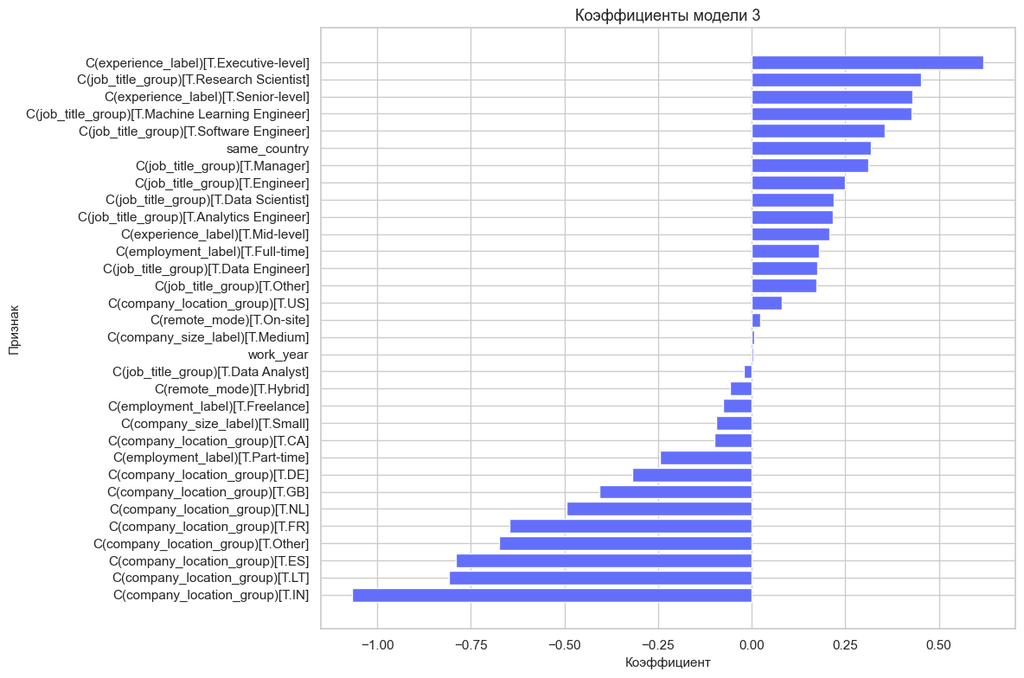

```python
coef_plot_3 = (
    coef_table_3.reset_index()
    .rename(columns={"index": "term"})
    .query("term != 'Intercept'")
    .sort_values("coef")
)

plt.figure(figsize=(12, 8))
plt.barh(coef_plot_3["term"], coef_plot_3["coef"], color="#636EFA")
plt.title("Коэффициенты модели 3")
plt.xlabel("Коэффициент")
plt.ylabel("Признак")
plt.tight_layout()
plt.show()
```

Коэффициенты третьей модели подтверждают, что новые признаки были добавлены не зря.

Во-первых, опыт остаётся одним из ключевых факторов: по сравнению с `Entry-level` группа `Executive-level` связана примерно с `+85.8%` к ожидаемой зарплате, `Senior-level` — с `+53.6%`, а `Mid-level` — с `+22.9%`. Это означает, что даже после учёта роли и географии опыт сохраняет самостоятельную и сильную связь с уровнем оплаты.

Во-вторых, очень информативным оказался `job_title_group`. Например, `Machine Learning Engineer` связан примерно с `+53.1%`, `Research Scientist` — с `+57.3%`, `Software Engineer` — с `+42.6%`, а `Data Scientist` — с `+24.5%` относительно базовой категории. Это как раз и подтверждает, что одной только информации об уровне опыта было недостаточно: конкретная роль действительно сильно влияет на зарплату.

В-третьих, география компании даёт крупные и устойчивые эффекты. По сравнению с базовой страной многие категории оказываются связаны с заметно более низким уровнем зарплаты. Это означает, что модель наконец начинает учитывать один из важнейших источников различий на рынке труда — различие между локальными рынками.

Наконец, переменная `same_country` оказывается положительной и статистически значимой: совпадение страны сотрудника и компании связано примерно с `+37.6%` к ожидаемой зарплате. Это сильный и интересный результат, который указывает на важность географической структуры найма.

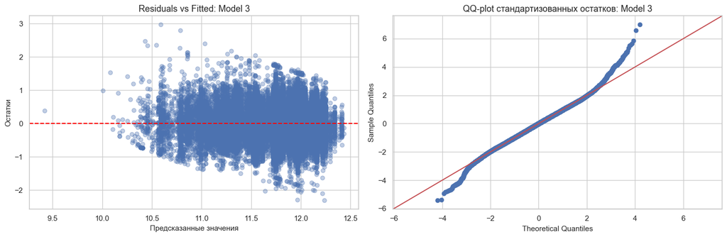

```python
influence_3 = model_3.get_influence()
standardized_residuals_3 = influence_3.resid_studentized_internal

fig, axes = plt.subplots(1, 2, figsize=(15, 5))

axes[0].scatter(model_3.fittedvalues, model_3.resid, alpha=0.35)
axes[0].axhline(0, color="red", linestyle="--")
axes[0].set_title("Residuals vs Fitted: Model 3")
axes[0].set_xlabel("Предсказанные значения")
axes[0].set_ylabel("Остатки")

qqplot(standardized_residuals_3, line="45", ax=axes[1])
axes[1].set_title("QQ-plot стандартизованных остатков: Model 3")

plt.tight_layout()
plt.show()
```

```python
hetero_model_3 = pd.DataFrame(
    [
        heteroskedasticity_report(model_3, "Model 3"),
    ]
)

hetero_model_3.round(4)
```

|  | model | bp_lm_stat | bp_lm_pvalue |
| --- | --- | --- | --- |
| 0 | Model 3 | 1826.4378 | 0.0 |

```python
vif_model_3 = calculate_vif(model_3_df, formula_3)
vif_model_3.sort_values("VIF", ascending=False).round(4).head(25)
```

|  | feature | VIF |
| --- | --- | --- |
| 0 | Intercept | 9.090340e+06 |
| 30 | C(company_location_group)[T.US] | 1.953170e+01 |
| 21 | C(company_location_group)[T.CA] | 9.356100e+00 |
| 18 | C(job_title_group)[T.Other] | 7.056200e+00 |
| 25 | C(company_location_group)[T.GB] | 6.303000e+00 |
| 29 | C(company_location_group)[T.Other] | 4.820100e+00 |
| 14 | C(job_title_group)[T.Data Scientist] | 3.356900e+00 |
| 13 | C(job_title_group)[T.Data Engineer] | 3.329300e+00 |
| 3 | C(experience_label)[T.Senior-level] | 3.090400e+00 |
| 12 | C(job_title_group)[T.Data Analyst] | 3.043600e+00 |
| 2 | C(experience_label)[T.Mid-level] | 2.978100e+00 |
| 20 | C(job_title_group)[T.Software Engineer] | 2.639100e+00 |
| 15 | C(job_title_group)[T.Engineer] | 2.470100e+00 |
| 17 | C(job_title_group)[T.Manager] | 2.252200e+00 |
| 16 | C(job_title_group)[T.Machine Learning Engineer] | 2.210100e+00 |
| 9 | C(employment_label)[T.Full-time] | 1.969300e+00 |
| 10 | C(employment_label)[T.Part-time] | 1.917100e+00 |
| 22 | C(company_location_group)[T.DE] | 1.784000e+00 |
| 28 | C(company_location_group)[T.NL] | 1.771800e+00 |
| 27 | C(company_location_group)[T.LT] | 1.606200e+00 |
| 24 | C(company_location_group)[T.FR] | 1.593100e+00 |
| 19 | C(job_title_group)[T.Research Scientist] | 1.492900e+00 |
| 11 | C(job_title_group)[T.Analytics Engineer] | 1.484700e+00 |
| 23 | C(company_location_group)[T.ES] | 1.438000e+00 |
| 26 | C(company_location_group)[T.IN] | 1.416600e+00 |

Диагностика третьей модели показывает смешанную, но в целом хорошую картину.

С одной стороны, гетероскедастичность полностью не исчезла: тест Бройша—Пагана по-прежнему отвергает гипотезу о постоянной дисперсии ошибок (`p-value = 0.00`). Это означает, что даже расширенная спецификация не делает модель идеальной, и использование робастных стандартных ошибок HC3 остаётся оправданным.

Проверка мультиколлинеарности уже не выглядит столь безоблачной, как во второй модели, но остаётся контролируемой. У части географических признаков VIF повышается, что естественно: страны и укрупнённые географические группы частично связаны между собой. Однако это не выглядит критической проблемой, а скорее разумной платой за более сильную и содержательную спецификацию.

## 2.10. Сравнение второй и третьей спецификаций

Теперь можно сравнить уже две логарифмические модели между собой. Это методологически более чистое сравнение, потому что и вторая, и третья спецификация построены на одной и той же зависимой переменной — `log_salary`.

Значит, здесь уже можно уверенно сравнивать `R2`, `Adjusted R2`, `AIC`, `BIC`, `RMSE` и `MAE` как показатели качества моделей в одной шкале.

```python
comparison_log_models = pd.DataFrame(
    [
        {
            "model": "Model 2: baseline log model",
            "n_obs": int(model_2.nobs),
            "r2": model_2.rsquared,
            "adj_r2": model_2.rsquared_adj,
            "aic": model_2.aic,
            "bic": model_2.bic,
            "rmse": np.sqrt(mean_squared_error(model_df["log_salary"], model_2.fittedvalues)),
            "mae": mean_absolute_error(model_df["log_salary"], model_2.fittedvalues),
        },
        {
            "model": "Model 3: enriched log model",
            "n_obs": int(model_3.nobs),
            "r2": model_3.rsquared,
            "adj_r2": model_3.rsquared_adj,
            "aic": model_3.aic,
            "bic": model_3.bic,
            "rmse": np.sqrt(mean_squared_error(model_3_df["log_salary"], model_3.fittedvalues)),
            "mae": mean_absolute_error(model_3_df["log_salary"], model_3.fittedvalues),
        },
    ]
)

comparison_log_models.round(4)
```

|  | model | n_obs | r2 | adj_r2 | aic | bic | rmse | mae |
| --- | --- | --- | --- | --- | --- | --- | --- | --- |
| 0 | Model 2: baseline log model | 71913 | 0.1599 | 0.1598 | 98247.8784 | 98358.077 | 0.4790 | 0.3766 |
| 1 | Model 3: enriched log model | 71913 | 0.3382 | 0.3379 | 81134.7660 | 81437.812 | 0.4252 | 0.3355 |

Сравнение второй и третьей моделей показывает, что расширенная спецификация выигрывает практически по всем ключевым критериям.

`R2` растёт с `0.1599` до `0.3382`, а `Adjusted R2` — с `0.1598` до `0.3379`. Это означает, что улучшение не сводится к механическому увеличению числа факторов: новые признаки действительно приносят содержательно полезную информацию.

Одновременно снижаются `AIC` и `BIC`, что особенно важно: несмотря на усложнение модели, выигрыш в качестве подгонки оказывается достаточно большим, чтобы оправдать эту дополнительную сложность.

Также уменьшаются `RMSE` и `MAE`, то есть расширенная модель в среднем точнее описывает логарифм зарплаты. Иными словами, третья спецификация не только лучше объясняет вариацию зависимой переменной, но и даёт меньшую ошибку предсказания в той же самой шкале.

## 2.11. Выбор финальной модели

На этом этапе выбор финальной модели выглядит достаточно уверенным.

Вторая спецификация уже была заметно лучше базовой модели на `salary_in_usd`: она давала более удобную интерпретацию коэффициентов и улучшала форму распределения остатков.

Однако третья модель идёт дальше и решает главную проблему второй спецификации — нехватку сильных признаков. Добавление роли, географии компании и признака `same_country` существенно увеличивает объясняющую способность модели и делает структуру различий в зарплатах гораздо более реалистичной.

При этом модель остаётся интерпретируемой: коэффициенты по опыту, ролям и географии можно осмысленно читать и обсуждать, а использование HC3 помогает сохранить корректность статистических выводов в условиях сохраняющейся гетероскедастичности.

Поэтому в этой работе именно третью спецификацию разумно выбрать как финальную.

## 2.12. Вывод по разделу

Во втором разделе были последовательно оценены три спецификации линейной регрессии методом МНК.

Первая модель на `salary_in_usd` оказалась полезной как отправная точка: она позволила увидеть основные содержательные эффекты, но выявила серьёзные проблемы с поведением остатков и предпосылками модели.

Вторая спецификация на `log_salary` улучшила интерпретацию коэффициентов и сделала форму распределения ошибок заметно спокойнее. Это подтвердило, что логарифмирование зарплаты для такого типа данных действительно оправдано.

Третья спецификация показала, что основное ограничение предыдущих моделей было связано не только с выбором шкалы зависимой переменной, но и с нехваткой сильных объясняющих признаков. После добавления укрупнённой должности, географии компании и признака `same_country` качество модели выросло очень заметно: `R2` увеличился до `0.338`, а остальные метрики на той же шкале также улучшились.

Таким образом, финальная версия модели в этой работе — это расширенная логарифмическая спецификация. Она не устраняет всех ограничений полностью, но лучше остальных моделей сочетает содержательную интерпретируемость, статистическую устойчивость и качество подгонки.